# A3: SPL Library Checkouts

### Introduction

The Seattle Public Library has available checkout data from 2005 to present. This data set provides a variety of information about checkouts for physical and electronic items. In this report, I am using a subset of this data, which covers all items checked out in 2022-2023 so far. I am focusing on exploring trends pertaining to checkouts for popular materials, publishers, and usage classes over the course of this specific time period. I chose these trends because they provide valuable insights about the preferences of Seattle Public Library patrons, as well as the materials and publishers that are most often checked out at SPL. Analyzing these trends can also provide insights about large-scale societal trends, such as shifts in the preferred medium of reading over the span of a year. This information can be useful not only for the SPL system, but also for researchers and policymakers analyzing literacy-related trends.

### The Dataset

The Seattle Public Library collects, owns, and publishes this data. Before 2017, the Library did not actively collect comprehensive checkout data that would allow us to explore specific trends. However, an innovative artwork installed at Central Library had been collecting useful checkout data since 2005, enabling the library to gather and publish data from before 2017 as well. There are 2757014 observations and 13 features in the dataset used for this report.

The parameters of this data are: Usage Class, Checkout Type, Checkout Year, Checkout Month, Checkouts, Title, ISBN, Creator, Subjects, Publisher, and Publication Year.

The data was generated through the the SPL checkout system, which automatically records information about each item that is checked out by library patrons. The data is collected electronically through the checkout system and is compiled and published for analysis.

The data was collected by The Seattle Public Library to analyze trends in library usage and to inform decision-making related to library services. The data can help identify popular materials, checkout patterns, and areas for improvement or resource allocation in library services.

There are many ethical questions that we need to consider when working with this data. This data contains information about books checked out by library users, which is often not collected at all due to libraries’ intention of protecting patron identity. While analyzing this data, we need to be mindful that the data is not used in a way that could identify individual patrons. It is also important to ensure that the data being used is reliable and accurate. If there are potential errors or inaccuracies, they should be addressed in the analysis itself. Lastly, we need to be cautious of what potential biases may exist in the data, and where they originally stem from (for example, poor data collection techniques or misrepresentation of certain patrons/publishers).

There are many significant challenges and limitations that come along with analyzing such a big dataset. Since this data only reflects checkouts from The Seattle Public Library, it may not be representative of all libraries or their checkout trends. This information may be heavily influenced by the location of this library, as compared to other libraries in the nation. Additionally, the data set only goes back to 2005, so any trends or patterns prior to that time cannot be analyzed. Some of the data such as publisher or creator may also be incomplete which could affect the accuracy of our analysis. Additionally, there is a very limited amount of information provided in this data set, which may be due to the library’s intention of keeping patron identity as protected as possible. However, this hinders our ability to make claims based on observed trends, as we need more detailed information to be able to infer future trends.

### Materials Chart

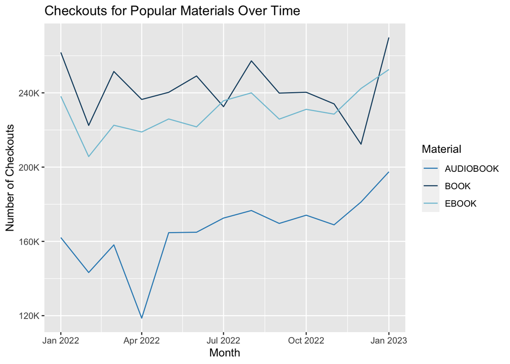

This chart explores trends in checkouts for books, ebooks, and audiobooks over the span of 2022 to the first month of 2023 (present). A line chart is suitable to represent this data since it shows trends and changes in the number of checkouts for each material type over time. It allows us to easily compare the performance of the different materials and to identify any patterns that may be emerging over time. From the chart, we can observe that there are fluctuations in the number of checkouts for each material type over the course of the year. For example, there seems to be a significant decline in checkouts in April of 2022, especially for audiobooks. This may be due to many COVID-19 related restrictions lifting during this month, which opened up avenues for patrons to continue other activities and thus spend less time reading. By analyzing these patterns, we can gain insights into the preferences of library patrons and how they may be changing over time. This information can help library managers make more informed decisions about resource allocation and future investments.

### Publishers Chart

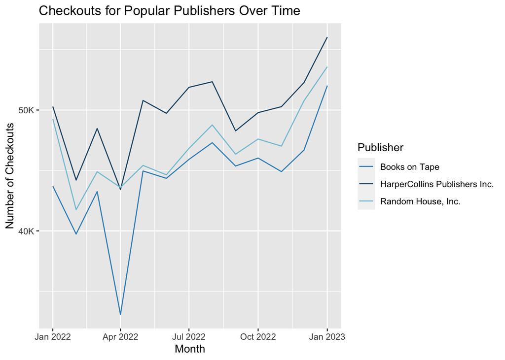

### Usage Class Chart

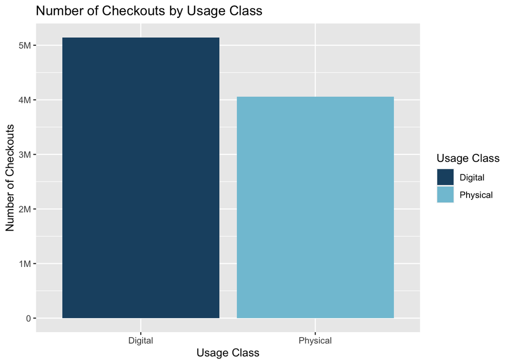

This chart displays the total number of checkouts and splits them according to the usage class they fall under. This data is best represented as a bar chart because it compares two distinct categories: digital materials and physical materials. We can clearly deduce patterns in this data by analyzing the length of each bar, as they represent the number of checkouts for each category. This data reveals that digital materials are relatively more popular than physical materials in terms of checkouts. Digital materials may be becoming more popular over time since more people have access to devices that allow them to easily borrow and read or listen to digital content. Borrowing and reading a physical copy may require more time and energy, while digital copies can be obtained in minutes. This information is important for libraries and publishers to understand as they consider their collections and marketing strategies. They may need to allocate more resources towards promoting digital content, or they may need to focus on promoting the benefits of physical materials to encourage more people to check them out.